# Applied Statistics

Claire He

**Packages and data**

[output not shown]

[output not shown]

[output not shown]

# Hypothesis Testing Based Approach

## Question a) Forward selection

For forward selection we start with null model and add predictors according to 5% cutoff at p-value rule.

```r
forward_selection <- function(data){
  M1 <- lm(mpg ~1, data=data)

  minpvalue = 0
  for (i in 1:length(data)){
    Mf <- lm(mpg ~., data=data)

    Add1 = add1(M1, scope=Mf, data=data, test='F')
    print(Add1)
    minpvalue <- min(Add1$"Pr(>F)"[-1])
    print(minpvalue)
    if  (minpvalue<0.05){
    var_name = rownames(Add1[which(Add1$"Pr(>F)"== minpvalue),])
    print(var_name)
    M1 <- update(M1, reformulate(paste0(". +",var_name), "."))
    }
    else{
    break
    }
  }
  return(summary(M1))
}

forward_selection(data=mtcars)
```

```
Single term additions

Model:
mpg ~ 1
       Df Sum of Sq     RSS     AIC F value    Pr(>F)
<none>              1126.05 115.943
cyl     1    817.71  308.33  76.494 79.5610 6.113e-10 ***
disp    1    808.89  317.16  77.397 76.5127 9.380e-10 ***
hp      1    678.37  447.67  88.427 45.4598 1.788e-07 ***
drat    1    522.48  603.57  97.988 25.9696 1.776e-05 ***
wt      1    847.73  278.32  73.217 91.3753 1.294e-10 ***
qsec    1    197.39  928.66 111.776  6.3767  0.017082 *
vs      1    496.53  629.52  99.335 23.6622 3.416e-05 ***
am      1    405.15  720.90 103.672 16.8603  0.000285 ***
gear    1    259.75  866.30 109.552  8.9951  0.005401 **
carb    1    341.78  784.27 106.369 13.0736  0.001084 **
---
Signif. codes:
0 ‘***’ 0.001 ‘**’ 0.01 ‘*’ 0.05 ‘.’ 0.1 ‘ ’ 1
[1] 1.293959e-10
[1] "wt"
Single term additions

Model:
mpg ~ wt
       Df Sum of Sq    RSS    AIC F value   Pr(>F)
<none>              278.32 73.217
cyl     1    87.150 191.17 63.198 13.2203 0.001064 **
disp    1    31.639 246.68 71.356  3.7195 0.063620 .
hp      1    83.274 195.05 63.840 12.3813 0.001451 **
drat    1     9.081 269.24 74.156  0.9781 0.330854
qsec    1    82.858 195.46 63.908 12.2933 0.001500 **
vs      1    54.228 224.09 68.283  7.0177 0.012926 *
am      1     0.002 278.32 75.217  0.0002 0.987915
gear    1     1.137 277.19 75.086  0.1189 0.732668
carb    1    44.602 233.72 69.628  5.5343 0.025646 *
---
Signif. codes:
0 ‘***’ 0.001 ‘**’ 0.01 ‘*’ 0.05 ‘.’ 0.1 ‘ ’ 1
[1] 0.001064282
```

[output cut: 21 more lines]

```
    Min      1Q  Median      3Q     Max
-4.2893 -1.5512 -0.4684  1.5743  6.1004

Coefficients:
            Estimate Std. Error t value Pr(>|t|)
(Intercept)  39.6863     1.7150  23.141  < 2e-16 ***
wt           -3.1910     0.7569  -4.216 0.000222 ***
cyl          -1.5078     0.4147  -3.636 0.001064 **
---
Signif. codes:
0 ‘***’ 0.001 ‘**’ 0.01 ‘*’ 0.05 ‘.’ 0.1 ‘ ’ 1

Residual standard error: 2.568 on 29 degrees of freedom
Multiple R-squared:  0.8302,    Adjusted R-squared:  0.8185
F-statistic: 70.91 on 2 and 29 DF,  p-value: 6.809e-12
```

## Question b) Backward selection

For backward selection we start with full model and drop predictors according to 5% cutoff at p-value rule.

```r
backward_selection <- function(data){
  Mf <- lm(mpg~., data=data)
  maxpvalue = 1
  for (i in 1:length(data)){
    maxpvalue <- max(summary(Mf)$coefficients[-1,4])
    if(maxpvalue < 0.05){
      break
    }
    else {
    var_name = names(which(summary(Mf)$coefficients[-1,4]== maxpvalue))
    print(summary(Mf))
    print(var_name)
    Mf <- update(Mf, reformulate(paste0(". -",var_name), "."))

    }
  }
  print(summary(Mf))
}

backward_selection(mtcars)
```

```
Call:
lm(formula = mpg ~ ., data = data)

Residuals:
    Min      1Q  Median      3Q     Max
-3.4506 -1.6044 -0.1196  1.2193  4.6271

Coefficients:
            Estimate Std. Error t value Pr(>|t|)
(Intercept) 12.30337   18.71788   0.657   0.5181
cyl         -0.11144    1.04502  -0.107   0.9161
disp         0.01334    0.01786   0.747   0.4635
hp          -0.02148    0.02177  -0.987   0.3350
drat         0.78711    1.63537   0.481   0.6353
wt          -3.71530    1.89441  -1.961   0.0633 .
qsec         0.82104    0.73084   1.123   0.2739
vs           0.31776    2.10451   0.151   0.8814
am           2.52023    2.05665   1.225   0.2340
gear         0.65541    1.49326   0.439   0.6652
carb        -0.19942    0.82875  -0.241   0.8122
---
Signif. codes:
0 ‘***’ 0.001 ‘**’ 0.01 ‘*’ 0.05 ‘.’ 0.1 ‘ ’ 1

Residual standard error: 2.65 on 21 degrees of freedom
Multiple R-squared:  0.869, Adjusted R-squared:  0.8066
F-statistic: 13.93 on 10 and 21 DF,  p-value: 3.793e-07

[1] "cyl"

Call:
lm(formula = mpg ~ disp + hp + drat + wt + qsec + vs + am + gear +
    carb, data = data)

Residuals:
    Min      1Q  Median      3Q     Max
-3.4286 -1.5908 -0.0412  1.2120  4.5961

Coefficients:
            Estimate Std. Error t value Pr(>|t|)
```

[output cut: 157 more lines]

```
-3.4811 -1.5555 -0.7257  1.4110  4.6610

Coefficients:
            Estimate Std. Error t value Pr(>|t|)
(Intercept)   9.6178     6.9596   1.382 0.177915
wt           -3.9165     0.7112  -5.507 6.95e-06 ***
qsec          1.2259     0.2887   4.247 0.000216 ***
am            2.9358     1.4109   2.081 0.046716 *
---
Signif. codes:
0 ‘***’ 0.001 ‘**’ 0.01 ‘*’ 0.05 ‘.’ 0.1 ‘ ’ 1

Residual standard error: 2.459 on 28 degrees of freedom
Multiple R-squared:  0.8497,    Adjusted R-squared:  0.8336
F-statistic: 52.75 on 3 and 28 DF,  p-value: 1.21e-11
```

Backward selection has lead to select the model
$$mpg \sim wt + qsec + am$$

# Best subset selection

## Question c) Best subset selection

We now want to perform best subset for variable selection.

```r
fit <- lm(mpg ~ ., data=mtcars)
best.lm <- ols_step_best_subset(fit)
install.packages(c("leaps", "faraway"))
install.packages("olsrr")
```

```
Error in install.packages : Updating loaded packages
```

```r
install.packages("ggpubr")
```

```
Error in install.packages : Updating loaded packages
```

```r
best.lm
```

```
                Best Subsets Regression
-------------------------------------------------------
Model Index    Predictors
-------------------------------------------------------
     1         wt
     2         cyl wt
     3         wt qsec am
     4         hp wt qsec am
     5         disp hp wt qsec am
     6         disp hp drat wt qsec am
     7         disp hp drat wt qsec am gear
     8         disp hp drat wt qsec am gear carb
     9         disp hp drat wt qsec vs am gear carb
    10         cyl disp hp drat wt qsec vs am gear carb
-------------------------------------------------------

                                                   Subsets Regression Summary
---------------------------------------------------------------------------------------------------------------------------------
                       Adj.        Pred
Model    R-Square    R-Square    R-Square     C(p)        AIC        SBIC        SBC         MSEP       FPE       HSP       APC
---------------------------------------------------------------------------------------------------------------------------------
  1        0.7528      0.7446      0.7087    11.6270    166.0294    74.3734    170.4266    296.9167    9.8572    0.3199    0.2801
  2        0.8302      0.8185      0.7904     1.2187    156.0101    66.1903    161.8730    211.2280    7.2101    0.2354    0.2049
  3        0.8497      0.8336      0.7946     0.1026    154.1194    65.7138    161.4481    193.9735    6.8017    0.2239    0.1933
  4        0.8579      0.8368      0.8021     0.7900    154.3274    67.2299    163.1218    190.4637    6.8547    0.2280    0.1948
  5        0.8637      0.8375      0.7984     1.8462    154.9740    69.3073    165.2341    189.8793    7.0080    0.2361    0.1992
  6        0.8667      0.8347      0.7855     3.3700    156.2687    71.9258    167.9946    193.4796    7.3170    0.2502    0.2079
  7        0.8681      0.8296      0.7619     5.1472    157.9333    74.8058    171.1250    199.7867    7.7358    0.2691    0.2198
  8        0.8687      0.8230      0.7316     7.0496    159.7853    77.7959    174.4427    207.9040    8.2358    0.2922    0.2340
  9        0.8689      0.8153      0.7035     9.0114    161.7271    80.8277    177.8502    217.4086    8.8041    0.3194    0.2502
 10        0.8690      0.8066      0.6538    11.0000    163.7098    83.8728    181.2986    228.1554    9.4379    0.3512    0.2682
---------------------------------------------------------------------------------------------------------------------------------
AIC: Akaike Information Criteria
 SBIC: Sawa's Bayesian Information Criteria
 SBC: Schwarz Bayesian Criteria
 MSEP: Estimated error of prediction, assuming multivariate normality
 FPE: Final Prediction Error
 HSP: Hocking's Sp
 APC: Amemiya Prediction Criteria
```

```r
best.lm2 <- regsubsets(mpg~ ., data=mtcars, nvmax=10)
```

We can read the significant covariates obtained through best subset model selection. It chooses for each subset sizes:

- for 1 predictor the model $mpg \sim wt$,
- for 2 predictors it chooses $mpg \sim cyl+wt$,
- for 3 predictors it chooses $mpg \sim wt + qsec + am$,
- for 4 it chooses $mpg \sim hp+wt + qsec + am$,
- for 5 it chooses $mpg \sim disp+hp+wt + qsec + am$,
- for 6 it chooses $mpg \sim disp+hp+wt + qsec + am+drat$,
- for 7 it chooses $mpg \sim disp+hp+wt + qsec + am+drat+gear$,
- for 8 it chooses $mpg \sim disp+hp+wt + qsec + am+drat+gear+carb$
- and for 9 it chooses $mpg \sim disp+hp+wt + qsec + am+drat+gear+ carb +vs$

## Question d) Model fit vs AIC, BIC, GCV, LOOCV and adjusted R2

*ols_step_best_subset* yields AIC, BIC and adjusted R2, we want to know the GCV and LOOCV metrics for our best subsets. We can obtain GCV using *regsubset* that gives us the RSS for the same best subset models. For LOOCV we have to compute it manually as follows:

```r
#Retrieving the best models for each size
varlist <- as.list(as.list(strsplit(best.lm$predictors, " ")))
new.lm <- function(x) {
    lm(reformulate(x, 'mpg'), data = mtcars)
}

# LOOCV function for each model
loocv <- function(fit){
  h=lm.influence(fit)$h
  mean((residuals(fit)/(1-h))^2)
}

# Best subset LOOCV
best_loocv <- function(list){
cv.li <- c(1:10)
for (i in 1:10){
  cv.li[i] <- loocv(new.lm(list[[i]]))
}
return(cv.li)
}

best_loocv(varlist)
```

```
 [1] 10.250712  7.376451  7.228234  6.963568  7.092947
 [6]  7.548634  8.376991  9.444218 10.433151 12.181558
```

```r
model_size <- c(1:10)
n <- rep(10, times=10)
criterion <- cbind(
  x      = model_size,
  AIC    = best.lm$aic,
  BIC    = best.lm$sbc,
  AdjR2  = best.lm$adjr,
  GCV    = summary(best.lm2)$rss/(n-model_size)^2,
  LOOCV  = best_loocv(varlist)
)
```

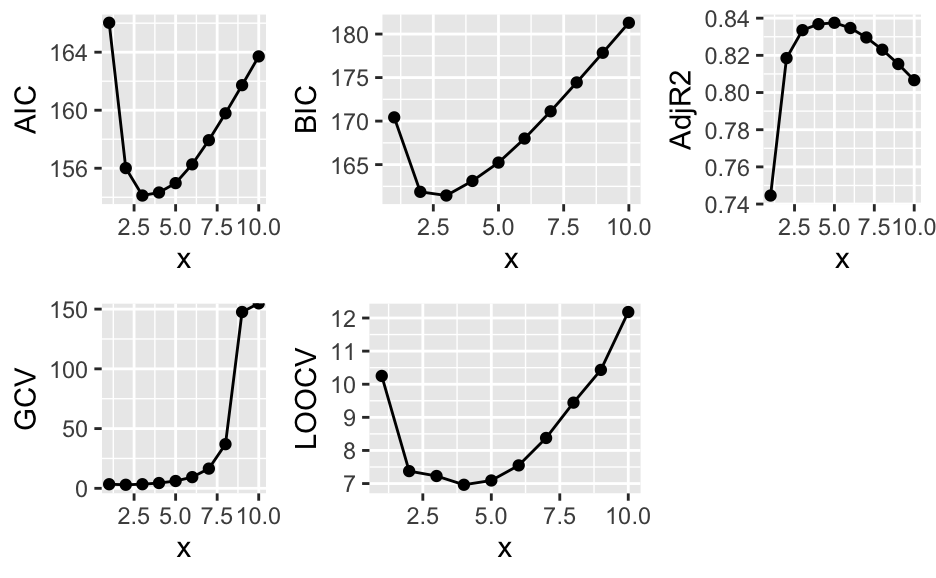

```r
criterion <- as.data.frame.matrix(criterion)
p1 <- ggplot(criterion, aes(x, AIC)) +
  geom_line()+geom_point()
p2 <- ggplot(criterion, aes(x, BIC)) +
  geom_line()+geom_point()
p3 <- ggplot(criterion, aes(x, GCV)) +
  geom_line()+geom_point()
p4 <- ggplot(criterion, aes(x, AdjR2)) +
  geom_line()+geom_point()
p5 <- ggplot(criterion, aes(x, LOOCV)) +
  geom_line()+geom_point()
ggarrange(p1, p2, p4, p3, p5, widths = c(1.5,2))
```

The curves are not monotonic except for GCV at a glance - but zooming in we can see that even GCV is not monotonic. We shouldn’t expect a monotonic curve, this has to do with the trade-off between variance and bias: with all variables, we have better fit, however variance grows because the noise adds up as well for each added variables.

```r
criterion$x[which(criterion$AIC == min(criterion$AIC))]
```

```
[1] 3
```

```r
criterion$x[which(criterion$BIC == min(criterion$BIC))]
```

```
[1] 3
```

```r
criterion$x[which(criterion$AdjR2 == max(criterion$AdjR2))]
```

```
[1] 5
```

```r
criterion$x[which(criterion$GCV == min(criterion$GCV))]
```

```
[1] 2
```

```r
criterion$x[which(criterion$LOOCV == min(criterion$LOOCV))]
```

```
[1] 4
```

We see that the best model size for AIC among best subsets is 3, for BIC as well we select 3, to maximise ajusted R square we choose the best subset model of size 5, for GCV size 2 and for LOOCV size 4.

## Question e) Comparison of criteria

```r
summary(best.lm2)
```

```
Subset selection object
Call: regsubsets.formula(mpg ~ ., data = mtcars, nvmax = 10)
10 Variables  (and intercept)
     Forced in Forced out
cyl      FALSE      FALSE
disp     FALSE      FALSE
hp       FALSE      FALSE
drat     FALSE      FALSE
wt       FALSE      FALSE
qsec     FALSE      FALSE
vs       FALSE      FALSE
am       FALSE      FALSE
gear     FALSE      FALSE
carb     FALSE      FALSE
1 subsets of each size up to 10
Selection Algorithm: exhaustive
          cyl disp hp  drat wt  qsec vs  am  gear carb
1  ( 1 )  " " " "  " " " "  "*" " "  " " " " " "  " "
2  ( 1 )  "*" " "  " " " "  "*" " "  " " " " " "  " "
3  ( 1 )  " " " "  " " " "  "*" "*"  " " "*" " "  " "
4  ( 1 )  " " " "  "*" " "  "*" "*"  " " "*" " "  " "
5  ( 1 )  " " "*"  "*" " "  "*" "*"  " " "*" " "  " "
6  ( 1 )  " " "*"  "*" "*"  "*" "*"  " " "*" " "  " "
7  ( 1 )  " " "*"  "*" "*"  "*" "*"  " " "*" "*"  " "
8  ( 1 )  " " "*"  "*" "*"  "*" "*"  " " "*" "*"  "*"
9  ( 1 )  " " "*"  "*" "*"  "*" "*"  "*" "*" "*"  "*"
10  ( 1 ) "*" "*"  "*" "*"  "*" "*"  "*" "*" "*"  "*"
```

We note that AIC and BIC pick model size 3, LOOCV size 4 and adjusted R square size 5. These models have overlapping covariates. On the other hand, model 2 is selected using GCV and uses covariate *cyl* that is never chosen by the other criteria. The difference of result using GCV can be explained by the fact that our data has 32 observations, we’d expect for a good pick of model that the GCV score is approximately equal to Mallow’s Cp (which is loosely related to our other metrics as well) when the number of observation is large enough: $GCV(\mathcal{M})= \frac{RSS_{\mathcal{M}}}{(n-|\mathcal{M}|)^2} \approx RSS_{\mathcal{M}} \big( 1 + \frac{2|\mathcal{M}|}{n}\big) \approx C_p = RSS_{\mathcal{M}} + 2\hat{\sigma}^2 |\mathcal{M}|$. We also see that the choice of LOOCV and GCV is really different which can be surprising at first. Both take in account the effect of influential points through leverage, however GCV takes an average of the leverage which in this case can be skewed by a very high leverage point in this very small number of observations. On the other hand, we see that adjusted R square picks out the highest number of covariates. Indeed it is based on the R-square which always grows with more predictors (as it is focused on fitting the data well) with a correction to avoid overfitting by adjusting for model complexity. However we see here that despite the correction it selects the most complicated model. AIC and BIC are similar criteria which are information based so it is no surprise they pick out the same model.

## Question f) Bootstrap for model selection

We want to apply residual resampling 100 times for each best subsets model.

```r
boot_res <- function(x) {
    lm1 <- lm(reformulate(x, 'mpg'), data = mtcars)
    residuals <- resid(lm1)
    res <- sample(1:length(residuals), replace = TRUE)
    boot.Y  <-  mtcars[,1] + residuals[res]
    mtcars  <- mtcars %>% mutate(fitted = boot.Y)
    boot.lm <- lm(reformulate(x, 'fitted'), data = mtcars)
    return(boot.lm)
}
# one bootstrap sample along residuals for best subset model
AIC(boot_res(varlist[[2]]))
```

```
[1] 181.2927
```

```r
aic <- list()
bic <- list()
adjr2 <- list()
looCV <- list()
gcv <- list()
model_num <- list()
it <- list()
for (i in 1:100){
  for (var in 1:length(varlist)){
    # bootstrap
    boot.lm <- boot_res(varlist[[var]])
    # computing our criteria
    aic <- append(aic, AIC(boot.lm))
    bic <-  append(bic, BIC(boot.lm))
    adjr2 <-  append(adjr2, summary(boot.lm)$adj.r.squared)
    RSS <-  sum(resid(boot.lm)^2)
    looCV <- append(looCV, loocv(boot.lm))
    gcv <-  append(gcv, RSS/(10-length(varlist[[var]]))^2)
    # storing which model
    model_num <- append(model_num, var)
    it <- append(it, i)
  }
}
install.packages("olsrr")
install.packages("ggpubr")
```

```
Error in install.packages : Updating loaded packages
```

```r
boot_crit <- data.frame(unlist(model_num), unlist(it), unlist(aic), unlist(bic), unlist(adjr2), unlist(looCV),  unlist(gcv))
```

```r
boot_crit <- boot_crit %>%
        rename("num"= "unlist.model_num.", "res_it"="unlist.it.","AIC"="unlist.aic.", "BIC"="unlist.bic.", "AdjR2"="unlist.adjr2.", "LOOCV"="unlist.looCV.", "GCV"="unlist.gcv.")
boot_crit
```

| num | res_it | AIC | BIC | AdjR2 | LOOCV | GCV |
| --- | --- | --- | --- | --- | --- | --- |
| 1 | 1 | 194.8135 | 199.2107 | 0.5480675 | 25.360572 | 8.447174 |
| 2 | 1 | 175.8833 | 181.7462 | 0.7387730 | 13.681728 | 5.558496 |
| 3 | 1 | 176.9471 | 184.2758 | 0.6663947 | 14.697110 | 7.050765 |
| 4 | 1 | 175.4673 | 184.2617 | 0.6969545 | 14.167842 | 8.608018 |
| 5 | 1 | 171.4643 | 181.7245 | 0.7962810 | 12.579123 | 10.275309 |
| 6 | 1 | 171.1432 | 182.8691 | 0.7435195 | 12.003193 | 14.931815 |
| 7 | 1 | 176.9516 | 190.1432 | 0.7256491 | 13.865304 | 29.900389 |
| 8 | 1 | 178.4007 | 193.0580 | 0.7012939 | 19.595201 | 66.127573 |
| 9 | 1 | 175.8018 | 191.9249 | 0.7568099 | 14.864784 | 229.101695 |
| 10 | 1 | 182.9622 | 200.5510 | 0.7274893 | 20.313799 | Inf |

[output cut: 990 more lines]

```r
model_freqAIC <- list()
model_freqBIC <- list()
model_freqLOOCV <- list()
model_freqGCV<- list()
model_freqAdjR2 <- list()
for (i in 1:max(boot_crit$res_it)){
  subset = filter(boot_crit, res_it == i)
  model_freqAIC <- append(model_freqAIC, boot_crit[which(subset$AIC == min(subset$AIC)),]$num)
  model_freqBIC <- append(model_freqBIC, boot_crit[which(subset$BIC == min(subset$BIC)),]$num)
  model_freqGCV <- append(model_freqGCV, boot_crit[which(subset$GCV == min(subset$GCV)),]$num)
  model_freqAdjR2 <- append(model_freqAdjR2, boot_crit[which(subset$AdjR2 == max(subset$AdjR2)),]$num)
  model_freqLOOCV <- append(model_freqLOOCV, boot_crit[which(subset$LOOCV == min(subset$LOOCV)),]$num)

}


model_freqLOOCV <- as.data.frame(table(unlist(model_freqLOOCV)))
model_freqGCV<- as.data.frame(table(unlist(model_freqGCV)))
model_freqAIC<- as.data.frame(table(unlist(model_freqAIC)))
model_freqBIC<-as.data.frame(table(unlist(model_freqBIC)))
model_freqAdjR2<- as.data.frame(table(unlist(model_freqAdjR2)))

#freqdf = data.frame(LOOCV =model_freqLOOCV, GCV = model_freqGCV, AIC = model_freqAIC, BIC = model_freqBIC, AdjR2 = model_freqAdjR2)
```

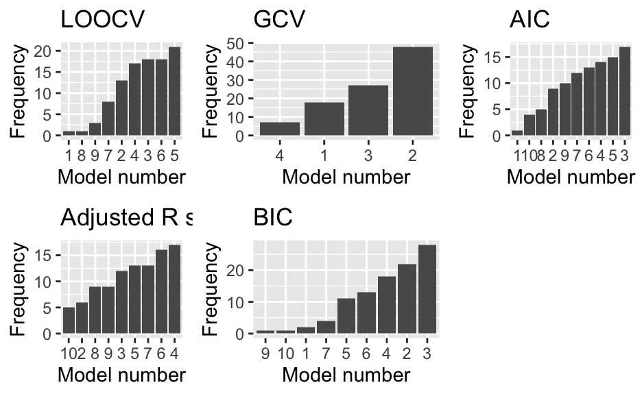

```r
p1 <- ggplot(model_freqLOOCV, aes(x =  reorder(Var1, Freq), y=Freq)) +
  geom_bar(stat = "identity")
p1 <- p1 + ggtitle("LOOCV") +
  xlab("Model number") + ylab("Frequency")

p2<- ggplot(model_freqGCV, aes(x =  reorder(Var1, Freq), y=Freq)) +
  geom_bar(stat = "identity")
p2 <- p2 + ggtitle("GCV") +
  xlab("Model number") + ylab("Frequency")

p3 <- ggplot(model_freqAdjR2, aes(x =  reorder(Var1, Freq), y=Freq)) +
  geom_bar(stat = "identity")
p3 <- p3 + ggtitle("Adjusted R square") +
  xlab("Model number") + ylab("Frequency")

p4 <- ggplot(model_freqAIC, aes(x =  reorder(Var1, Freq), y=Freq)) +
  geom_bar(stat = "identity")
p4 <- p4 + ggtitle("AIC") +
  xlab("Model number") + ylab("Frequency")

p5 <- ggplot(model_freqBIC, aes(x =  reorder(Var1, Freq), y=Freq)) +
  geom_bar(stat = "identity")
p5 <- p5 + ggtitle("BIC") +
  xlab("Model number") + ylab("Frequency")
ggarrange(p1, p2, p4, p3, p5, widths = c(1.5,2))
```

With bootstrapping, we see that LOOCV chooses most often model 5. However this choice only happens about 22% of our resampling, and we can see that 4,3,6 are also model often selected with LOOCV (about 17% of the time). On the other and, GCV chooses model 2 about 50% of our resampling. AIC, BIC both choose model 3, however that choice happens almost 30% of the time with BIC against 18% with AIC. AIC also chooses model 4 and 5 around 15% of the time. In contrasts, the second most frequent selected model which is 2 for BIC has frequency around 20%. So 3 stands out more for BIC than AIC as a choice (can be explained by the fact that BIC is more consistent while AIC more efficient). For adjusted R2 we see two models that jump out, model 4 and model 6 (which have similar covariates).

# LASSO

## Question g) Creating noisy variables

We create noisy variables by permutating each variable randomly.

```r
my.data <- mtcars %>% mutate(
  cyl1 = sample(cyl),
  disp1 = sample(disp),
  hp1 = sample(hp),
  drat1 = sample(drat),
  wt1 = sample(wt),
  qsec1 = sample(qsec),
  vs1 = sample(vs),
  am1 = sample(am),
  gear1 = sample(gear),
  carb1 = sample(carb))
```

## Question h) Solution paths

LASSO regression and solution paths. Note that we don’t rescale since it is performed as default in glmnet.

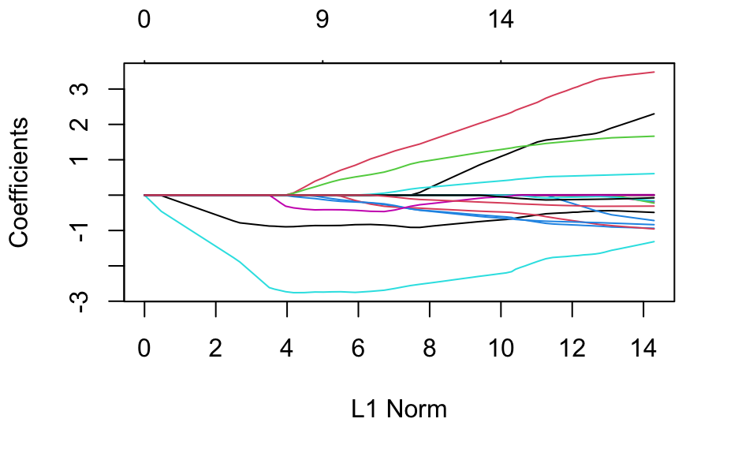

```r
lasso.fit <- glmnet(my.data[,-1], my.data[,1])
plot(lasso.fit)
```

## Question i) Variable selection

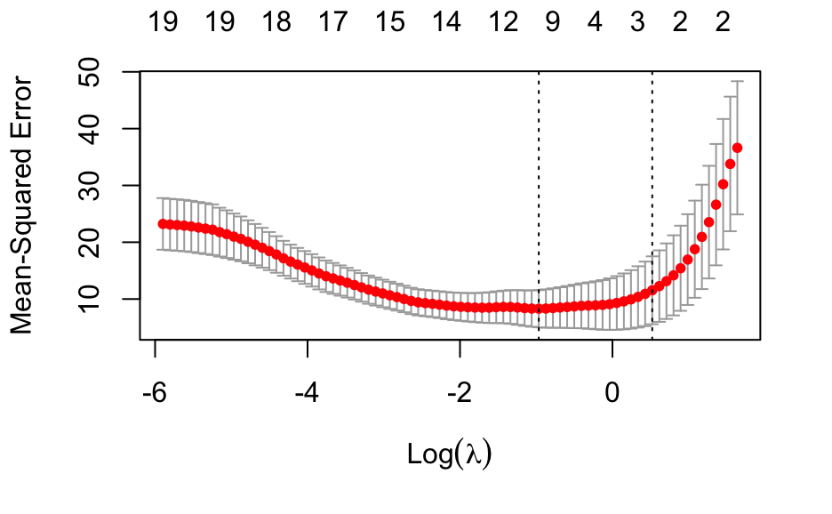

```r
lassoCV.fit <- cv.glmnet(data.matrix(my.data[,-1]),my.data[,1], nfolds=10)
plot(lassoCV.fit)
```

```r
install.packages("ggpubr")
c(lassoCV.fit$lambda.min,lassoCV.fit$lambda.1se)
```

```
[1] 0.3803991 1.6854043
```

```r
round(log(c(lassoCV.fit$lambda.min,lassoCV.fit$lambda.1se)),2)
```

```
[1] -0.97  0.52
```

See that the variables selected through lasso with cross validation are *cyl*, *hp* and *wt*. None of the noisy variables have been selected.

```r
coef(lassoCV.fit, m=lassoCV.fit$lambda.min)
```

```
21 x 1 sparse Matrix of class "dgCMatrix"
                      s1
(Intercept) 32.956547399
cyl         -0.822871059
disp         .
hp          -0.004701802
drat         .
wt          -2.202101851
qsec         .
vs           .
am           .
gear         .
carb         .
cyl1         .
disp1        .
hp1          .
drat1        .
wt1          .
qsec1        .
vs1          .
am1          .
gear1        .
carb1        .
```

```r
coef(lassoCV.fit, s=lassoCV.fit$lambda.1se )
```

```
21 x 1 sparse Matrix of class "dgCMatrix"
                      s1
(Intercept) 32.956547399
cyl         -0.822871059
disp         .
hp          -0.004701802
drat         .
wt          -2.202101851
qsec         .
vs           .
am           .
gear         .
carb         .
cyl1         .
disp1        .
hp1          .
drat1        .
wt1          .
qsec1        .
vs1          .
am1          .
gear1        .
carb1        .
```

## Question j) Iterating the procedure

```r
freqlist= list()
for (i in 1:100){
  # generating noisy variables
  my.data <- mtcars %>% mutate(
    cyl1 = sample(cyl),
    disp1 = sample(disp),
    hp1 = sample(hp),
    drat1 = sample(drat),
    wt1 = sample(wt),
    qsec1 = sample(qsec),
    vs1 = sample(vs),
    am1 = sample(am),
    gear1 = sample(gear),
    carb1 = sample(carb))
  # LASSO CV with 10 folds
  lassoCV.fit <- cv.glmnet(data.matrix(my.data[,-1]),my.data[,1], nfolds=10)
  # get coefficients
  coef_df <- coef_df %>% mutate(coef.name = dimnames(coef(lassoCV.fit))[[1]], coef.value = matrix(coef(lassoCV.fit)))
  # get non zeros coef and variables in our list to count frequencies
  freqlist <- append(freqlist, list(subset(coef_df, coef.value != 0)$coef.name))
}
```

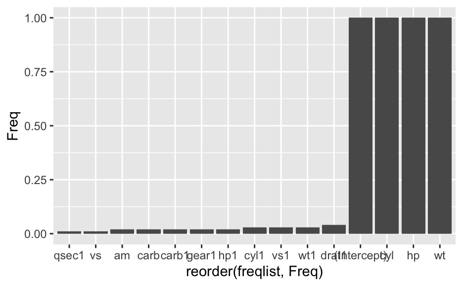

```r
# collapsing the list
freqlist = unlist(freqlist)
# get frequencies
frequencies <- table(freqlist)/100
df <- as.data.frame(frequencies)
ggplot(df, aes(x =  reorder(freqlist, Freq), y=Freq)) +
  geom_bar(stat = "identity")
```

# Summary of all variable selection procedures

*Best subset selection methods*

- AIC : 18 % $mpg \sim wt + qsec + am$
- BIC : 30% $mpg \sim wt + qsec + am$
- GCV : 50% $mpg \sim cyl+wt$
- LOOCV : 22% $mpg \sim disp+hp+wt + qsec + am$
- AdjR2 : 18 % $mpg \sim hp +wt + qsec + am$